# GR5242 Final Project: Feature Visualization for CNN

#### Team Member： Jielai Sheng, Yingbin Jiang, Bo Peng, Fan Gong

## Part 1. Introduction

Large Convolutional Network models have recently demonstrated impressive classification performance on the ImageNet benchmark. However there is no clear understanding of why they perform so well, or how they might be improved. So here comes feature visualization. In this project, we try to use two different methods and three different CNN model to get the insight about what is really going on in each of the layer and how CNN could get such a good result. Here are the brief summaries about our models and methods:

- **MINIST Dataset** (Six layers convolutional neural networks + two feature visualization mathods)
- **SVHN Dataset** (Six layers convolutional neural networks + one feature visualization mathods)
- **Cifar10 Dataset** (Six layers convolutional neural networks + two feature visualization methods)

### Feature Visualization Methods

We use two different ways to visualize the feature in each layer. The first method is called unpooling and deconvolution; the second method is called feature maximization.

#### (1) Deconvolution Method

This method uses unpooling and deconvolutional method to transfer the obtained feature map back to the original pixel space, which helps us to see which specific feature map is sensible to what kind of patterns. Here deconvolution is not inverse operation, but the transpose of convolutional layer.

#### (2) Deep Dream

Then let us see how these methods perform in different datasets and methods

## Part 2. Feature Visulization For MNIST

The MNIST database of handwritten digits has a training set of 55,000 examples, and a test set of 10,000 examples. The digits have been size-normalized and centered in a fixed-size image. It is a good database for people who want to try learning techniques and pattern recognition methods on real-world data while spending minimal efforts on preprocessing and formatting. Here we construct a 5 layers convolutional neural networks to perform image recognization and then use two methods we've introduced above to do feature visualization.

### 1. Pre-processing and Model Construction

#### (i) Load Data and Library :

```python
import tensorflow as tf
import numpy as np
import pickle
from tensorflow.python.platform import gfile
from random import randint
import os
import scipy.misc
from matplotlib import pyplot as plt
# load the minist dataset
from tensorflow.examples.tutorials.mnist import input_data
mnist = input_data.read_data_sets('../data/mnist', one_hot=True)
```

```
Extracting ../data/mnist/train-images-idx3-ubyte.gz
Extracting ../data/mnist/train-labels-idx1-ubyte.gz
Extracting ../data/mnist/t10k-images-idx3-ubyte.gz
Extracting ../data/mnist/t10k-labels-idx1-ubyte.gz
```

#### (ii) Define Helper Functions

Here we define some functions to help us construct CNN and visualize the features

```python
# This function aims to create the weight variable
def weight_varible(shape):
    initial = tf.truncated_normal(shape, stddev=0.1)
    return tf.Variable(initial)

# This function aims to create the bias variable
def bias_variable(shape):
    initial = tf.constant(0.1, shape=shape)
    return tf.Variable(initial)

# This function aims to construct convolution layer
def conv2d(x, W):
    return tf.nn.conv2d(x, W, strides=[1, 1, 1, 1], padding='SAME')

# This function aims to construct the max pooling layer
def max_pool_2x2(x):
    return tf.nn.max_pool(x, ksize=[1, 2, 2, 1], strides=[1, 2, 2, 1], padding='SAME')

def unpool(value, name='unpool'):
    '''
    This function aims to generate the unpooling layer

    parameter
    ---------
    value: A Tensor of shape [b, d0, d1, ..., dn, ch]

    return
    ------
    out: A Tensor of shape [b, 2*d0, 2*d1, ..., 2*dn, ch]
    '''
    with tf.name_scope(name) as scope:
        sh = value.get_shape().as_list()
        dim = len(sh[1:-1])
        out = (tf.reshape(value, [-1] + sh[-dim:]))
        for i in range(dim, 0, -1):
            out = tf.concat([out, out],i)
        out_size = [-1] + [s * 2 for s in sh[1:-1]] + [sh[-1]]
        out = tf.reshape(out, out_size, name=scope)
    return out

def plot_images(num_row, num_col, images, smooth=True):
    '''
    This function aims to make plots.

    Parameter
    ---------
    num_row: The number of row of the subplots
    num_col: The number of column of the subplots
    images: A numpy array has the shape [i, :, :].
            i is the number of picture we have.

    Return
    ------
    Show image directly on the notebook
    '''

    # Interpolation type.
    if smooth:
        interpolation = 'spline16'
    else:
        interpolation = 'nearest'

    # Create figure with sub-plots.
    fig, axes = plt.subplots(num_row, num_col, figsize = (20,8))

    # Adjust  spacing.
    plt.subplots_adjust(top=0.4, bottom=0.08, left=0.10, right=0.95, hspace=0.5,
                    wspace=0.35)

    # For each entry in the grid.
    for i, ax in enumerate(axes.flat):
        # Get the i'th image and only use the desired pixels.
        img = images[i, :, :]

        # Plot the image.
        ax.imshow(img, interpolation=interpolation, cmap='binary')
        ax.set_title('Feature_{}'.format(i+1))

        # Remove ticks.
        ax.set_xticks([])
        ax.set_yticks([])

    # Ensure the plot is shown correctly with multiple plots
    # in a single Notebook cell.
    plt.show()
```

### 2. CNN Model Construction and Training

```python
batchsize = 50
imagesize = 28

sess = tf.InteractiveSession()
# paras
W_conv1 = weight_varible([5, 5, 1, 32])
b_conv1 = bias_variable([32])

# conv layer-1
x = tf.placeholder(tf.float32, [None, 784])
x_image = tf.reshape(x, [-1, 28, 28, 1])

h_conv1 = tf.nn.relu(conv2d(x_image, W_conv1) + b_conv1)
h_pool1 = max_pool_2x2(h_conv1)

# conv layer-2
W_conv2 = weight_varible([5, 5, 32, 64])
b_conv2 = bias_variable([64])

h_conv2 = tf.nn.relu(conv2d(h_pool1, W_conv2) + b_conv2)
h_pool2 = max_pool_2x2(h_conv2)

# full connection
W_fc1 = weight_varible([7 * 7 * 64, 1024])
b_fc1 = bias_variable([1024])

h_pool2_flat = tf.reshape(h_pool2, [-1, 7 * 7 * 64])
h_fc1 = tf.nn.relu(tf.matmul(h_pool2_flat, W_fc1) + b_fc1)

# dropout
keep_prob = tf.placeholder(tf.float32)
h_fc1_drop = tf.nn.dropout(h_fc1, keep_prob)

# output layer: softmax
W_fc2 = weight_varible([1024, 10])
b_fc2 = bias_variable([10])

logits = tf.matmul(h_fc1_drop, W_fc2) + b_fc2

y_conv = tf.nn.softmax(logits)
y_ = tf.placeholder(tf.float32, [None, 10])

# model training
cross_entropy = -tf.reduce_sum(y_ * tf.log(y_conv))
train_step = tf.train.AdamOptimizer(1e-4).minimize(cross_entropy)

correct_prediction = tf.equal(tf.argmax(y_conv, 1), tf.argmax(y_, 1))
accuracy = tf.reduce_mean(tf.cast(correct_prediction, tf.float32))

sess.run(tf.global_variables_initializer())


for i in range(1000):
    batch = mnist.train.next_batch(50)

    if i % 100 == 0:
        train_accuacy = accuracy.eval(feed_dict={x: batch[0], y_: batch[1],
                                                 keep_prob: 1.0})
        ##t.eval() is a shortcut for calling tf.get_default_session().run(t)
        print("step %d, training accuracy %g"%(i, train_accuacy))
    train_step.run(feed_dict = {x: batch[0], y_: batch[1], keep_prob: 0.5})

# accuacy on test
print("test accuracy %g"%(accuracy.eval(feed_dict={x: mnist.test.images,
                                                   y_: mnist.test.labels,
                                                   keep_prob: 1.0})))
```

```
step 0, training accuracy 0.12
step 100, training accuracy 0.9
step 200, training accuracy 0.88
step 300, training accuracy 0.88
step 400, training accuracy 0.98
step 500, training accuracy 0.98
step 600, training accuracy 0.96
step 700, training accuracy 0.96
step 800, training accuracy 1
step 900, training accuracy 0.86
test accuracy 0.9663
```

### 3. Deconvolution Feature Visualization

Here we will use deconvolution method to perform feature visualization.

#### (i) Reconstruction From The First Convolutional Layer :

```python
# construct unpooling and deconvolutional layer
featuresReLu_1 = tf.placeholder(tf.float32,[None,14,14,32])
unPool_1 = unpool(featuresReLu_1) # unpooling
unReLu_1 = tf.nn.relu(unPool_1)
unBias_1 = unReLu_1
unConv_1 = tf.nn.conv2d_transpose(unBias_1, W_conv1,
                                  output_shape=[batchsize,28,28,1],
                                  strides=[1,1,1,1], padding="SAME")
```

```python
# Get the feature maps (after pooling) from the first layer
activations1 = h_pool1.eval(feed_dict={x: mnist.train.next_batch(50)[0],
                                       y_: mnist.train.next_batch(50)[1]})
print (activations1.shape)
```

```
(50, 14, 14, 32)
```

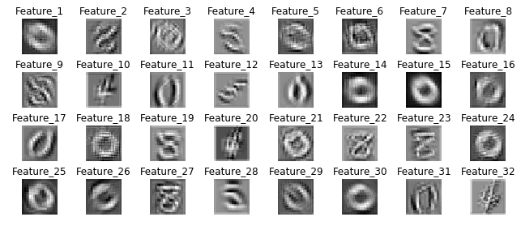

```python
"""
Get every feature map (1, 14, 14, 1) from activations1
then reconstruct the convolution layer
"""
plt.figure(num='CNV1',figsize=(10,8))
for i in range(32):
    isolated = activations1.copy()
    isolated[:,:,:,:i] = 0
    isolated[:,:,:,i+1:] = 0
    #These two lines set all other features other than feature i to 0

    totals = np.sum(isolated,axis=(1,2,3))
    best = np.argmax(totals,axis=0)
    """
    #choose the most obvious image in terms of i feature
    #These two lines are particular for batch of images.
    #That means choose one image from this batch of images
                       which feacture i can judge best.
    """
    pixelactive = unConv_1.eval(feed_dict={featuresReLu_1: isolated})
    #print(pixelactive.shape)
    #shape of every pixelactive is (50, 28, 28, 1)
    #batchsize=50 picsize=28*28 colors=1
    plt.subplot(4,8,i+1)
    plt.title('Feature_{}'.format(i+1))
    plt.imshow(pixelactive[best,:,:,0],cmap="gray")
    plt.axis('off')
plt.subplots_adjust(top=0.5, bottom=0.08, left=0.10, right=0.95, hspace=0.5,
                    wspace=0.35)
plt.show()
```

It is obvious that the images that restored from the first convolutional layer still keep a very clear pattern to tell us which number this image represent for. But if we see them more carefully, we find that each feature image starts to represent different peculiarity, which means each feature has different functionality to extract the key information. Here are the detailed analysis:

- **Feature Comparison:**
  1. By looking at these images which have a outline of number 0, we could compare their similarities and differences. Feature 11 has a more clear outline which means this feature has a function to identify the boundary. Also, feature 17 and 25, 26 have a function to identify the shadow inside of the number 0. Finally, even the feture 6 only shows us a vague '0', we could easily see that this feature can identify the boundary shadow which is very important in image recognition.
  2. With similar analysis as above, for the images that have a outline of number 8, feature 7, 19 could identify different part of the boundary shadow; feature 4 is sensible to the light since it hardly extracts shadow information.
- **Feature Grouping:**
  1. Boundary Detection Group. Features in this group have a function to detect the boundary of the number: Feature 7,11,13, 17.
  2. Shadow Detection Group. Features in this group have a function to detect the shadow: Feature 2, 6, 10, 13, 17, 31.
  3. Light Detection Group. Features in this group are sensible to light: Feature 4, 14, 15.

#### (ii) Reconstruction From The Second Convolutional Layer :

```python
#Get the feature maps from the second convolutional layer
activations2 = h_pool2.eval(feed_dict={x: mnist.train.next_batch(50)[0],
                                       y_: mnist.train.next_batch(50)[1]})
print (activations2.shape)
```

```
(50, 7, 7, 64)
```

```python
#Reconstruction from the layer CNV-2
featuresReLu_2 = tf.placeholder(tf.float32,[None,7,7,64])
unPool_2 = unpool(featuresReLu_2)
unReLu_2 = tf.nn.relu(unPool_2)
unBias_2 = unReLu_2
unBias_2

unConv_2 = tf.nn.conv2d_transpose(unBias_2, W_conv2,
                                  output_shape=[batchsize,14,14,32] ,
                                  strides=[1,1,1,1], padding="SAME")
unPool_1 = unpool(unConv_2)
unReLu_1 = tf.nn.relu(unPool_1)
unBias_1 = unReLu_1
unBias_1

unConv_1 = tf.nn.conv2d_transpose(unBias_1, W_conv1,
                                  output_shape=[batchsize,28,28,1] ,
                                  strides=[1,1,1,1], padding="SAME")
```

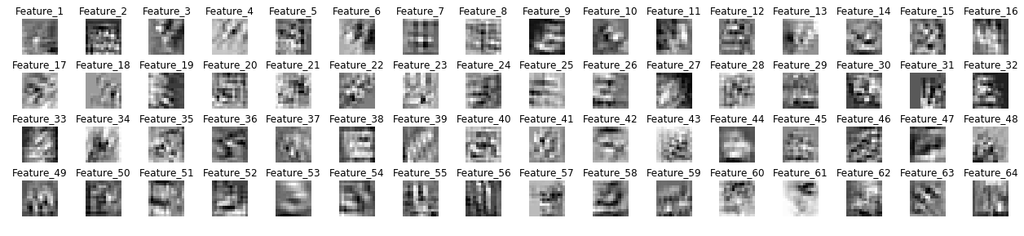

```python
plt.figure(num='CNV2',figsize=(20,8))
for i in range(64):
    isolated = activations2.copy()
    isolated[:,:,:,:i] = 0
    isolated[:,:,:,i+1:] = 0
    #These two lines set all other features other than feature i to 0
    #print (isolated.shape)
    totals = np.sum(isolated,axis=(1,2,3))
    best = np.argmax(totals,axis=0)
    """
    #choose the most obvious image in terms of i feature
    #These two lines are particular for batch of images.
    #That means choose one image from this batch of images
                       which feacture i can judge best.
    """

    pixelactive = unConv_2.eval(feed_dict={featuresReLu_2: isolated})
    #print(pixelactive.shape)
    #shape of every pixelactive is (50, 28, 28, 1)
    #batchsize=50 picsize=28*28 colors=1
    plt.subplot(4,16,i+1)
    plt.title('Feature_{}'.format(i+1))
    plt.imshow(pixelactive[best,:,:,0],cmap="gray")
    plt.axis('off')
plt.subplots_adjust(top=0.5, bottom=0.08, left=0.10, right=0.95, hspace=0.5,
                    wspace=0.35)
plt.show()
```

The images restored from the second convolutional layer are much complicated and totally different comparing with the images that restored from the first convolutional layer. That is because by using `relu` and `pooling` more, it is more hard to restore image back to its original appearance; in another word, the deep convolutional layer tries to extract more abstract and summarized features. Here are the detailed analysis:

- **Feature Grouping:**
  1. Textures Detection Group. Features in this group tend to detect the textures: Feature 7, 8, 12, 15, 16, 20
  2. Number Detection Group. Features in this group could identify the specific number: Feature 9, 26, 53, 58.
  3. Edges Detection Group. Features in this group have a function to detect the edges: Feature 27, 31, 58, 60
  4. Patterns Detection Group. Features in this group have a function to detect the patterns: Feature 39
  5. Shadow Detection Group. Features in this group try to extract the shadow information: Feature 9, 27, 32

### 4. Deep Dream Feature Visualization

Here we use deep dream method to perform feature visualization

#### (i) Define Helper Function :

The functions below use gradient ascent to maximize certain features inside the neural networks.

```python
def Deep_Dream_image(conv_layer, feature=0,
                   num_iterations=30):
    """
    This function aims to find an image that maximizes the feature given by the
    convlution layer and feature number

    Parameter
    ---------
    conv_layer: Tensor that identifying the convolutional layer to maximize.
             If None then use the last fully-connected layer
             before the softmax output.
    feature: Index into the layer for the feature to maximize.

    num_iteration: Number of optimization iterations to perform.

    show_progress: Boolean whether to show the progress.

    Return
    ------
    image.squeeze(): A numpy array contains the output information

    """

    # Create the loss-function that must be maximized.
    if conv_layer is None:

        # The loss-function is just the value of that feature.
        loss = tf.reduce_mean(logits[:, feature])
    else:

        # The loss-function is the average of
        # all the tensor-values for the given feature.
        loss = tf.reduce_mean(conv_layer[:, :, :, feature])

    # Get the gradient for the loss-function
    # with regard to the input image.
    gradient = tf.gradients(loss, x_image)

    # Use one of the training image as the test image
    image = mnist.train.next_batch(1)[0]
    image = image.reshape((28,28))

    # Perform a number of optimization iterations
    # to find the image that maximizes the loss-function.
    for i in range(num_iterations):
        # Reshape the array so it is a 4-rank tensor.
        img_reshaped = image[np.newaxis,:,:,np.newaxis]
        img_ori = img_reshaped.reshape((-1,784))

        # Create a feed-dict for inputting the image to the graph.
        feed_dict = {keep_prob: 1.0, x: img_ori, x_image: img_reshaped}


        # Calculate the predicted class-scores
        # as well as the gradient and the loss-value.
        pred, grad, loss_value = sess.run([y_conv, gradient, loss],
                                             feed_dict=feed_dict)

        # Squeeze the dimensionality for the gradient-array. (Back to 28 * 28)
        grad = np.array(grad).squeeze()

        # The gradient now tells us
        # how much we need to change the input image
        # in order to maximize the given feature.

        # Calculate the step-size for updating the image.
        # This step-size was found to give fast convergence.
        step_size = 1.0 / (grad.std() + 1e-8)

        # Gradient ascent.
        image += step_size * grad

        # Ensure all pixel-values in the image are between 0 and 1.
        image = np.clip(image, 0.0, 1.0)

    return image.squeeze()

# finds the images that maximize all the features of a layer
def Deep_Dream_images(conv_layer=None, num_iterations=30):
    """
    This functions aims to find 10 images that maximizes
    the 10 first features in the layer
    given by the convolution layer.

    Parameter
    ---------
    conv_layer : Tensor identifying the convolutional layer to maximize.
    If None then use the last layer before the softmax output.

    num_iterations: Number of optimization iterations to perform.

    show_progress: whether or not to show the progress
    """

    # Which layer are we using?
    if conv_layer is None:
        print("Final fully-connected layer before softmax.")
    else:
        print("Layer:", conv_layer.name)

    # Initialize the array of images.
    images = []

    # For each feature do the following.
    for feature in range(int(conv_layer.shape[-1])):
        #print("Optimizing image for feature no.", feature)

        # Find the image that maximizes the given feature
        image = Deep_Dream_image(conv_layer=conv_layer, feature=feature,
                               num_iterations=num_iterations)

        # Squeeze the dim of the array.
        image = image.squeeze()

        # Append to the list of images.
        images.append(image)

    # Convert to numpy-array so we can index all dimensions easily.
    images = np.array(images)

    # Plot the images.
    plot_images(num_row = 4, num_col = int(int(conv_layer.shape[-1])/4),
                images=images)
```

#### (ii) Maximize The Features In First Convolutional Layer :

Here we will use the functions we generated above to visualize the feature.

```
Layer: Relu:0
```

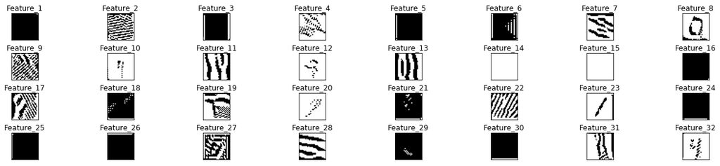

```python
Deep_Dream_images(h_conv1)
```

We know that Deep Dream Method tries to maximize certain features in our first convolutional layer. So in some sense these images tell us what kind of information each feature wants to extract.

Let us then compare the grouping results above with our previous deconvolution output images.

[figure not shown]

So, we could see, these two method do have some consistency and could give us a very clear way what kind of information our features identify.

#### (iii) Maximize The Features In Second Convolutional Layer :

```
Layer: Relu_1:0
```

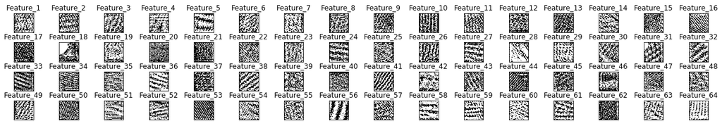

```python
Deep_Dream_images(h_conv2)
```

For the features in the second convolutional layer, it appears to be harder to explain just like in the first method. But we still can find some interesting pattern. And this time, I will directly compare it with our previous deconvolution results to generate some insights. Here are the detailed analysis:

1. **Texture Analysis**: we have seen that as the neural networks going deep, the features tend to be more abstract since information has been summarised. In that case, most of the feature will tend to extract more generalized information and texture is one of the most important one. See here most of the features have some stripy textures and most of their matched images will have the same appearance.
2. **Pattern Analysis**: Pattern is another important information that deep layer features want to extract. For example if we look at the feature 56, it has a clear pattern. And when we look at the matched image below, it also prove our assumption.
3. **Parts Analysis** : Even in the second layer, there are still some features could identify parts of the number information. For example feature 28, feature 32. So these features have a very strong sense to identify these specific numbers.

[figure not shown]

## Part 3. Feature Visualization for SVHN

SVHN is a real-world image dataset for developing machine learning and object recognition algorithms with minimal requirement on data preprocessing and formatting. It can be seen as similar in flavor to MNIST (e.g., the images are of small cropped digits), but incorporates an order of magnitude more labeled data (over 600,000 digit images) and comes from a significantly harder, unsolved, real world problem (recognizing digits and numbers in natural scene images). SVHN is obtained from house numbers in Google Street View images. (http://ufldl.stanford.edu/housenumbers/)

```python
import tensorflow as tf
from tensorflow.python.platform import gfile
import numpy as np
import scipy.io as sio
import scipy.misc
import math
import pickle
from random import randint
import os
import os.path
from datetime import datetime
from matplotlib import pyplot as plt
```

### 1. Preparing the tools

#### (i) Define Data Functions :

```python
def GCN(data_dir, ratio):
    ''' Perform image transformation Global Contraction Nornimlization

    Arguments:
    ----------
        data_dir: the path to the SVHN, the data is in .mat format
        ratio: test and train ratio

    Return:
    ----------
        images after GCN transformation
    '''

    train_data = sio.loadmat(data_dir)
    x_train = train_data['X']
    y_train = train_data['y']
    y_train[y_train == 10] = 0
    x_train = x_train.transpose((3,0,1,2))
    x_train.astype(float)
    x_gray = np.dot(x_train, [[0.2989],[0.5870],[0.1140]])

    imsize = x_gray.shape[0]
    mean = np.mean(x_gray, axis=(1,2), dtype=float)
    std = np.std(x_gray, axis=(1,2), dtype=float, ddof=1)
    std[std < 1e-4] = 1
    x_GCN = np.zeros(x_gray.shape, dtype=float)
    for i in np.arange(imsize):
        x_GCN[i,:,:] = (x_gray[i,:,:] - mean[i]) / std[i]
    nums = x_GCN.shape[0]
    x_GCN = x_GCN.reshape((nums,-1))
    data = np.hstack((y_train,x_GCN))
    np.random.shuffle(data)
    cut=math.floor(nums*ratio)
    val,train = data[:cut,:], data[cut:,:]

    print("\n------- GCN done -------")
    return train, val
```

```python
def read_SVHN(data_dir, ratio, batch_size):
    ''' read SCVN function images are 32 * 32 and in gray scale

    Args:
    ----------
        data_dir: the path to the SVHN, the data is in .mat format
        ratio: test and train ratio
        batch_size: number of train images trained per time

    Return:
    ----------
        image_list: the first element of image_list is
                    the train batch the second is the validation batch
        label_list: the first element of label_list is
                    the train batch the second is the validation batch
    '''
    train,val = GCN(data_dir, ratio)
    img_width = 32
    img_height = 32
    img_depth = 1
    label_bytes = 1
    image_bytes = 1024
    record_bytes = 1025

    with tf.name_scope('input'):
        images_list = []
        label_batch_list = []
        for train_val in [train, val]:
            q = tf.train.input_producer(train_val)
            input_data = q.dequeue()

            label = tf.slice(input_data , [0], [1])
            label = tf.cast(label, tf.int32)

            image_raw = tf.slice(input_data , [1], [1024])
            image_raw = tf.reshape(image_raw, [1, 32, 32])
            image = tf.transpose(image_raw, (1,2,0))
            image = tf.cast(image, tf.float32)
            images, label_batch = tf.train.batch([image, label],
                                                batch_size = batch_size,
                                                num_threads = 16,
                                                capacity= 2000)

            n_classes = 10
            label_batch = tf.one_hot(label_batch, depth = n_classes)

            label_batch_list.append(tf.reshape(label_batch,
                                               [batch_size, n_classes]))
            images_list.append(images)


        return images_list, label_batch_list
```

#### (ii) Define CNN Helper Functions :

```python
def conv(layer_name, x, out_channels, kernel_size=[5,5], stride=[1,1,1,1]):
    '''Convolution op wrapper, use RELU activation after convolution

    Args:
    ----------
        layer_name: e.g. conv1, pool1...
        x: input tensor, [batch_size, height, width, channels]
        out_channels: number of output channels (or comvolutional kernels)
        kernel_size: the size of convolutional kernel, VGG paper used: [3,3]
        stride: A list of ints. 1-D of length 4. VGG paper used: [1, 1, 1, 1]
        is_pretrain: if load pretrained parameters, freeze all conv layers.
                     Depending on different situations,
                    you can just set part of conv layers to be freezed.
        the parameters of freezed layers will not change when training.

    Returns:
    ----------
        4D tensor
    '''

    in_channels = x.get_shape()[-1]
    with tf.variable_scope(layer_name):
        w = tf.get_variable(name='weights',
                            shape=[kernel_size[0],
                                   kernel_size[1],
                                   in_channels, out_channels],
                            initializer=tf.contrib.layers.xavier_initializer())
        # default is uniform distribution initialization
        b = tf.get_variable(name='biases',
                            shape=[out_channels],
                            initializer=tf.constant_initializer(0.0))
        x = tf.nn.conv2d(x, w, stride, padding='SAME', name='conv')
        x = tf.nn.bias_add(x, b, name='bias_add')
        x = tf.nn.relu(x, name='relu')
        return x


def pool(layer_name, x, kernel=[1,2,2,1], stride=[1,2,2,1]):
    '''Pooling operation

    Args:
    ----------
        x: input tensor
        kernel: pooling kernel, VGG paper used [1,2,2,1], the size of kernel is 2X2
        stride: stride size, VGG paper used [1,2,2,1]
        padding:'SAME'
    '''
    with tf.variable_scope(layer_name):
        x = tf.nn.max_pool(x, kernel, strides=stride, padding='SAME', name=layer_name)
        return x

def FC_layer(layer_name, x, out_nodes):
    '''Wrapper for fully connected layers with RELU activation as default

    Args:
    ----------
        layer_name: e.g. 'FC1', 'FC2'
        x: input feature map
        out_nodes: number of neurons for current FC layer
    '''
    shape = x.get_shape()
    size = shape[1].value * shape[2].value * shape[3].value

    with tf.variable_scope(layer_name):
        w = tf.get_variable('weights',
                            shape=[size, out_nodes],
                            initializer=tf.contrib.layers.xavier_initializer())
        b = tf.get_variable('biases',
                            shape=[out_nodes],
                            initializer=tf.constant_initializer(0.0))
        flat_x = tf.reshape(x, [-1, size]) # flatten into 1D

        x = tf.nn.bias_add(tf.matmul(flat_x, w), b)
        x = tf.nn.relu(x)
        return x

def final_layer(layer_name, x, out_nodes):
    '''Wrapper for fully connected layers without activation function

    Args:
    ----------
        layer_name: e.g. 'final_layer'
        x: input feature map
        out_nodes: number of neurons for current FC layer
    '''
    shape = x.get_shape()
    size = shape[-1].value
    with tf.variable_scope(layer_name):
        w = tf.get_variable('weights',
                            shape=[size, out_nodes],
                            initializer=tf.contrib.layers.xavier_initializer())
        b = tf.get_variable('biases',
                            shape=[out_nodes],
                            initializer=tf.constant_initializer(0.0))
        flat_x = tf.reshape(x, [-1, size]) # flatten into 1D
        x = tf.nn.bias_add(tf.matmul(flat_x, w), b)
        return x


def drop_out(layer_name, x, keep_prob = 0.5):
    '''Wrapper for drop_out layer

    Args:
    ----------
        layer_name: e.g. 'drop_out'
        x: input feature map
        kep_prob: the prob of a specific neuron is inactive
        for the next layer
    '''
    with tf.variable_scope(layer_name):
        x = tf.nn.dropout(x, keep_prob)
        return x


def lossFn(logits, labels):
    '''Lost function

    Args:
    ----------
        logits: Logits tensor, float - [batch_size, NUM_CLASSES].
        labels: Labels tensor

    Returns:
    ----------
        loss tensor
    '''

    with tf.variable_scope('loss') as scope:
        labels = tf.cast(labels, tf.int64)
        cross_entropy = tf.nn.softmax_cross_entropy_with_logits
                        (logits=logits, labels=labels, name='loss')
        loss = tf.reduce_mean(cross_entropy, name='loss')
        tf.summary.scalar(scope.name+'/loss', loss)
    return loss


def accuracyFn(logits, labels):
    """Evaluate the quality of the logits at predicting the label.

    Args:
    ----------
        logits: Logits tensor, float - [batch_size, NUM_CLASSES].
        labels: Labels tensor

    Returns:
    ----------
        accuracy tensor
    """
    with tf.name_scope('accuracy') as scope:
        correct = tf.equal(tf.argmax(logits, 1), tf.argmax(labels, 1))
        correct = tf.cast(correct, tf.float32)
        accuracy = tf.reduce_mean(correct)*100.0
        tf.summary.scalar(scope+'/accuracy', accuracy)

    return accuracy

def optimize(loss, learning_rate, global_step):
    '''optimization use AdamOptimizer

    Args:
    ----------
        loss: Loss tensor
        learning_rate: e10-4 is desired
        global_step: non trainable varible

    Returns:
    ----------
        train_op: train operation
    '''
    with tf.name_scope('optimizer'):
    # optimizer = tf.train.GradientDescentOptimizer(learning_rate=learning_rate)
        optimizer = tf.train.AdamOptimizer(learning_rate=learning_rate)
        train_op = optimizer.minimize(loss, global_step=global_step)
        return train_op
```

#### (iii) Define Visualizing Functions :

```python
def unpool(value, name='unpool'):
    """N-dimensional version of the unpooling operation from
    https://www.robots.ox.ac.uk/~vgg/rg/papers
    /Dosovitskiy_Learning_to_Generate_2015_CVPR_paper.pdf

    args:
    ----------
    A Tensor of shape [b, d0, d1, ..., dn, ch]

    return:
    ----------
    A Tensor of shape [b, 2*d0, 2*d1, ..., 2*dn, ch]
    """
    with tf.name_scope(name) as scope:
        shape = value.get_shape().as_list()
        dim = len(shape[1:-1])
        out = (tf.reshape(value, [-1] + shape[-dim:]))
        for i in range(dim, 0, -1):
            out = tf.concat([out, out],i)
        out_size = [-1] + [s * 2 for s in shape[1:-1]] + [shape[-1]]
        out = tf.reshape(out, out_size, name=scope)
    return out
```

```python
def display_features(v_name, pool_size, out_shape, p_v, figs, col_mp):
    """
    Use unpooling and deconvolution to visualize features
    with stored activation values

    args:
    ----------
    v_name = variable name of the conv/weight of the desired layer
    pool_size = size of the 4D tensor that comes out of the layer
    out_shape = size of the 4D tensor that goes into the layer
    figs = size of the output image
    col_mp = gray or rbd color mapping

    return:
    ----------
    Image of features of the specified layer
    """

    w = [v for v in tf.trainable_variables() if v.name == v_name][0]

    #Reconstruction from the layer CNV-1
    featuresReLu = tf.placeholder(tf.float32, pool_size)
    unPool = unpool(featuresReLu)
    unReLu = tf.nn.relu(unPool)
    unBias  = unReLu
    unConv = tf.nn.conv2d_transpose(unBias, w,
                                    output_shape=out_shape ,
                                    strides=[1,1,1,1], padding="SAME")

    plt.figure(figsize=(2.5*figs[0],2.5*figs[1]))
    for i in range(figs[0]*figs[1]):
        isolated = p_v.copy()
        isolated[:,:,:,:i] = 0
        isolated[:,:,:,i+1:] = 0
        #These two lines set all other features other than feature i to 0
        totals = np.sum(isolated,axis=(1,2,3))
        best = np.argmax(totals,axis=0)
        #Picking the one image from this batch of images
        #which feacture i can judge best.
        with tf.Session() as sess:
            sess.run(tf.global_variables_initializer())
            pixelactive = sess.run(unConv, feed_dict={featuresReLu: isolated})
        #print(pixelactive.shape)
        plt.subplot(figs[0],figs[1],i+1)
        plt.imshow(pixelactive[best,:,:,0],cmap = col_mp)
        plt.title('Feature_{}'.format(i+1))
        plt.axis('off')
    plt.subplots_adjust(top=0.5, bottom=0.08, left=0.10,
                        right=0.95, hspace=0.5, wspace=0.35)
    plt.show()
```

### 2. CNN Model Training

#### (i) Setting parameters :

```python
N_CLASSES = 10
IMG_W =  32
# resize the image,
#if the input image is too large, training will be very slow.
IMG_H = 32
RATIO = 0.1 # take 20% of dataset as validation data
BATCH_SIZE = 64
TEST_BATCH_SIZE = 20
CAPACITY = 2000
MAX_STEP = 10000
# with current parameters, it is suggested to use MAX_STEP>10k
learning_rate = 0.0001
# with current parameters, it is suggested to use learning rate<0.0001

data_dir = './data/SVHN/train_32x32.mat'
train_log_dir = './logs/SVHN/train'
val_log_dir = './logs/SVHN/val'
```

#### (ii) Training the model :

```python
with tf.name_scope('input'):

    image_batch, label_batch  = read_SVHN(data_dir = data_dir,
                                                        ratio = 0.1,
                                                        batch_size = 64)
    tra_image_batch = image_batch[0]
    tra_label_batch = label_batch[0]

    val_image_batch = image_batch[1]
    val_label_batch = label_batch[1]


x = tf.placeholder(tf.float32, shape=[BATCH_SIZE, IMG_W, IMG_H, 1])
y_ = tf.placeholder(tf.int16, shape=[BATCH_SIZE,N_CLASSES])


c1 = conv('conv1', x, 16)
p1 = pool('pool1', c1)

c2 = conv('conv2', p1, 64)
p2 = pool('pool2', c2)

c3 = conv('conv3', p2, 128)
p3 = pool('pool3', c3)

fc = FC_layer('fc4', p3, out_nodes = 64)
do = drop_out('drop_out', fc, keep_prob = 0.5)
logits = final_layer('softmax', do, out_nodes=N_CLASSES)

loss = lossFn(logits, y_)
accuracy = accuracyFn(logits, y_)

my_global_step = tf.Variable(0, name='global_step', trainable=False)
train_op = optimize(loss, learning_rate, my_global_step)
summary_op = tf.summary.merge_all()

with tf.Session() as sess:
    sess.run(tf.global_variables_initializer())

    coord = tf.train.Coordinator()
    threads = tf.train.start_queue_runners(sess=sess, coord=coord)
    tra_summary_writer = tf.summary.FileWriter(train_log_dir, sess.graph)
    val_summary_writer = tf.summary.FileWriter(val_log_dir, sess.graph)


    try:
        for step in np.arange(MAX_STEP):
            if coord.should_stop():
                break
            tra_images,tra_labels = sess.run([tra_image_batch, tra_label_batch])
            _, tra_loss, tra_acc = sess.run([train_op, loss, accuracy],
                                            feed_dict={x:tra_images, y_:tra_labels})

            if step % 5 == 0 or (step + 1) == MAX_STEP:

                print ('Step: %d, loss: %.4f, accuracy: %.4f%%'
                       % (step, tra_loss, tra_acc))
                _, summary_str = sess.run([train_op, summary_op],
                                          feed_dict={x: tra_images, y_: tra_labels})
                tra_summary_writer.add_summary(summary_str, step)

            if step % 5 == 0 or (step + 1) == MAX_STEP:
                val_images, val_labels = sess.run([val_image_batch, val_label_batch])
                val_loss, val_acc = sess.run([loss, accuracy],
                                             feed_dict={x:val_images,y_:val_labels})

                print('**Step %d, val loss = %.2f, val accuracy = %.2f%%**'
                      %(step, val_loss, val_acc))
                _, summary_str = sess.run([train_op, summary_op],
                                          feed_dict={x: val_images, y_: val_labels})
                val_summary_writer.add_summary(summary_str, step)

            if step == (MAX_STEP - 1):
                c1_v = sess.run(c1, feed_dict={x:tra_images})
                p1_v = sess.run(p1, feed_dict={c1:c1_v})
                c2_v = sess.run(c2, feed_dict={p1:p1_v})
                p2_v = sess.run(p2, feed_dict={c2:c2_v})
                c3_v = sess.run(c3, feed_dict={p2:p2_v})
                p3_v = sess.run(p3, feed_dict={c3:c3_v})

    except tf.errors.OutOfRangeError:
        print('Done training -- epoch limit reached')

    finally:
        coord.request_stop()
    coord.join(threads)
```

[figure not shown]

Because the number of training step is 10000, it may occurpy too many pages. We use a screen shots to present the result.

#### (iii) SVHN Model Structure :

[figure not shown]

#### (iv) SVHN Model Performance :

Train Set

[figure not shown]

### 3. Deconvolution Feature Visualization

We stored the activation values of one batch of images during the training session, after they undergo each layer. We now feed the stored activations, along with the conv/weights, into the unpooling and unconvoluting operations that we have defined above.

These operations project the activations back onto the 2D image space, with each 2D image correspond to each feature. We then respresent each feature by the image from this batch of images which the feacture can judge best.

By its nature, layers that are made up by convolution and pooling are intended to 'encode' the inputs, in the sense that they record certain information of the inputs, and while doing so, also discard some other information.

By visualizing the features, we attempt to see what these 'encoders' decide to record and what do they decide to discard.

#### (i) Reconstruction From The First Convolutional Layer (batch) :

After Layer 1: 16 features, each of size 16x16

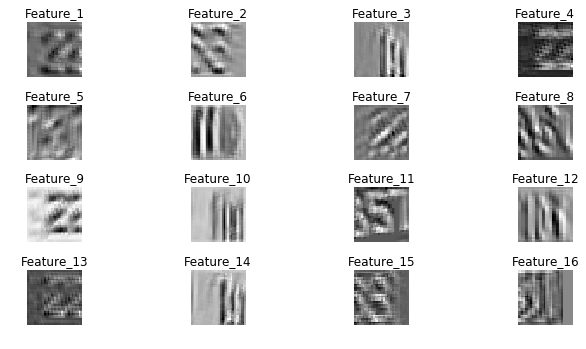

```python
display_features(
                v_name = "conv1/weights:0",
                pool_size = [None, 16,16,16],
                out_shape = [64,32,32,1],
                p_v = p1_v,
                figs = (4,4),
                col_mp="gray")
```

After the first feature selection layer, each input image of size 32x32 gets transformed into a stack of 16 feature layers, each of size 16x16. For each of the 16 features, we visualize it by picking the one image (from the stored 64 image batch) that the feature judges best. As could be seen from the pictures, the features after the first layer do not deviate from the original input by far.

- **Grouping:**  
  Group 1a: Feature 1, 4, 9, 13. They work best on the 'twisting' 2-digit house numbers (such as 22 and 33) on the right side of the image.  
  Group 1b: Feature 2, 15. Similar to group 1, they work best on the 'twisting' 2-digit house numbers on the left side.  
  Group 2a: Feature 3, 10, 14. They work best on the 'vertical' 2-digit house numbers (such as 11) on the right side of the image.  
  Group 2b: Feature 6. Similar to group 4, it works best on the 'vertical' 2-digit house numbers on the left side.  
  Group 3: Feature 5, 8, 11, 12. They work best on 3-digit house numbers that span across the image.

#### (ii) Reconstruction From The Second Convolutional Layer (batch) :

After Layer 2: 64 features, each of size 8x8

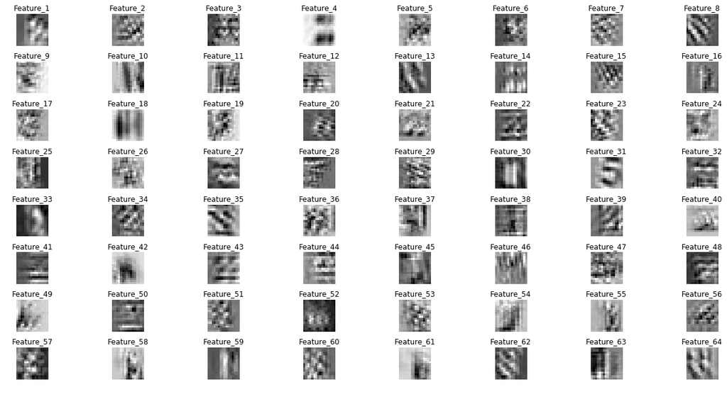

```python
display_features(
                v_name = "conv2/weights:0",
                pool_size = [None, 8, 8, 64],
                out_shape = [64,16,16,16],
                p_v = p2_v,
                figs = (8,8),
                col_mp="gray")
```

After the first feature selection layer, each stack of 16 layers of 16x16 features gets transformed into a stack of 64 features, each of size 8x8. For each of the 64 features, we visualize it by picking the one image (from the stored 64 image batch) that the feature judges best.

After 2 layers, the information contained in each layer is very limited and abstract.

- **Grouping:**  
  Feature 4, 18, 30, 59, 63 seem to be 'vertical' features.  
  Feature 7, 8, 15, 35, 62 seem to be the 'diagonal' features.  
  Feature 31 seems to be targeting specifically the number '5', possibly due to its propensity to get mixed up with other numbers.

#### (iii). Reconstruction From The First Convolutional Layer (one image) :

```python
n = 1 #index of the image we select
```

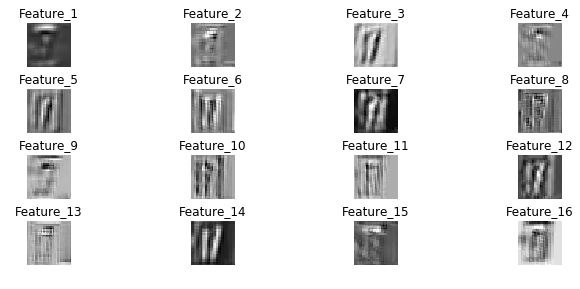

```python
w1 = [v for v in tf.trainable_variables() if v.name == "conv1/weights:0"][0]

#Reconstruction from the layer CNV-1
featuresReLu_1 = tf.placeholder(tf.float32,[None, 16, 16, 16])
unPool_1 = unpool(featuresReLu_1)
unReLu_1 = tf.nn.relu(unPool_1)
unBias_1 = unReLu_1

unConv_1 = tf.nn.conv2d_transpose(unBias_1, w1,
                                  output_shape=[64,32,32,1] ,
                                  strides=[1,1,1,1], padding="SAME")

plt.figure(num='layer1',figsize=(10,8))
for i in range(16):
    isolated = p1_v.copy()
    isolated[:,:,:,:i] = 0
    isolated[:,:,:,i+1:] = 0#These two lines set all other features other than feature i to 0
    with tf.Session() as sess:
        sess.run(tf.global_variables_initializer())
        pixelactive = sess.run(unConv_1, feed_dict={featuresReLu_1: isolated})
    #print(pixelactive.shape)
    plt.subplot(4,4,i+1)
    plt.imshow(pixelactive[n,:,:,0],cmap="gray")
    plt.title('Feature_{}'.format(i+1))
    plt.axis('off')
plt.subplots_adjust(top=0.5, bottom=0.08, left=0.10, right=0.95, hspace=0.5,
                    wspace=0.35)
plt.show()
```

The house number '17' gets represented by 16 features after Layer 1.

- **Grouping:**  
  Group I: Feature 1, 2, 4, 9, 13, 15, 16.  
  The number gets blurred by these features  
  Group II: Feature 3, 6, 12, 14.  
  These features best represent the number '17', with the right information perserved (the shape of number 17) and right information discard (the edge on the right-side of '7', for example)  
  Group III: Feature 3, 5, 7, 8, 10, 11, 12.  
  The number '17' gets recognized as a 3-digit number by these features, with the edge on the right-side of the '7' recognized as the third digit.
- **Analysis:**  
  In Section 3(i), we briefly summarized the 16 features into 3 groups by looking at the images that they judge best, with Group 1 judging 'twisting' 2-digit house numbers, Group 2 judging 'vertical' 2-digit ones, and Group 3 judging 3-digit ones. Cross referencing the grouping in this section with that in Section 3(i), we find that the two groupings correspond to each other surprisingly well.  
  Here, the Group I (1, 2, 4, 9, 13, 15, 16) correspond to Group 1 (1, 2, 4, 9, 13, 15). In these features, the house number '17' gets blurred into an unrecognizable haze, which is exactly what one would expect from features that target 'twisting' numbers (such as 22).  
  Group II (3, 6, 12, 14) correspond to Group 2 (3, 6, 10, 14). In these features, the house number '17' are neatly represented, with the correct information stored (the shape of the number), and the correct infromation discarded (the background). This is also a reasonable result, as Group 2 are the features that best judge 'vertical' 2-digit house numbers, and '17' is a 'vertical' 2-digit house number.  
  Group III (3, 5, 7, 8, 10, 11, 12) correspond to Group 3 (5, 8, 11, 12). In these features, the edge on the right-side of '7' is incorrectly recognized as a third number '1'. This coincide with our summarization of Group 3, which is that they recogizes 3-digit house numbers that span across the entire image.

#### (iv). Reconstruction From The Second Convolutional Layer (one image) :

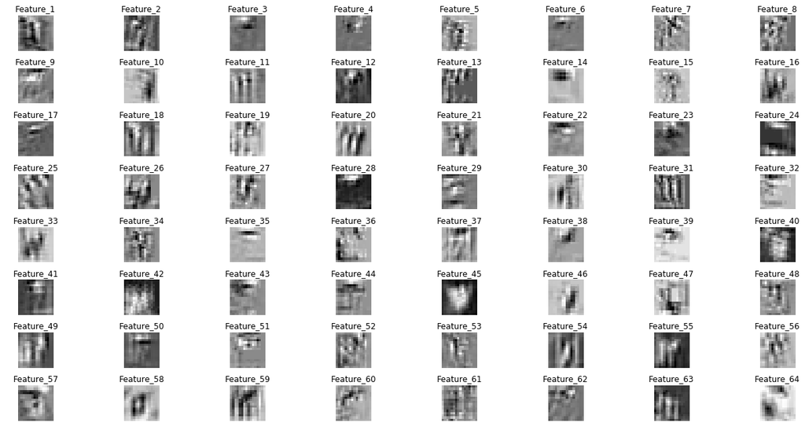

```python
w2 = [v for v in tf.trainable_variables() if v.name == "conv2/weights:0"][0]

#Reconstruction from the layer CNV-2
featuresReLu_2 = tf.placeholder(tf.float32,[None, 8, 8, 64])
unPool_2 = unpool(featuresReLu_2)
unReLu_2 = tf.nn.relu(unPool_2)
unBias_2 = unReLu_2
unConv_2 = tf.nn.conv2d_transpose(unBias_2, w2, output_shape=[64,16,16,16] , strides=[1,1,1,1], padding="SAME")

plt.figure(num='layer2',figsize=(20,20))
for i in range(64):
    isolated = p2_v.copy()
    isolated[:,:,:,:i] = 0
    isolated[:,:,:,i+1:] = 0
    #These two lines set all other features other than feature i to 0
    #print (isolated.shape)
    with tf.Session() as sess:
        sess.run(tf.global_variables_initializer())
        pixelactive = sess.run(unConv_2, feed_dict={featuresReLu_2: isolated})
    #print(pixelactive.shape)
    plt.subplot(8,8,i+1)
    plt.imshow(pixelactive[n,:,:,0],cmap="gray")
    plt.title('Feature_{}'.format(i+1))
    plt.axis('off')
plt.subplots_adjust(top=0.5, bottom=0.08, left=0.10, right=0.95, hspace=0.5,
                    wspace=0.35)
plt.show()
```

As in Section 3(ii), the features of house number '17' are perhaps too abstract for human to interpret after Layer 2. However, one could still notice that the number '17' gets represented well by the features that we categorized as 'vertical' ones in Section 3(ii), i.e., Feature 18, 30, 59, 63, etc.

## Part 4. Feature Visulization For Cifar10

### 1. Pre-processing

#### (i) Import Library:

```python
import tensorflow as tf
import numpy as np
from tensorflow.python.platform import gfile
from random import randint
import os
from matplotlib import pyplot as plt
from IPython.display import clear_output
from io import BytesIO
```

#### (ii) Define several functions:

```python
def unpickle(file):
    import pickle
    with open(file, 'rb') as fo:
        dict = pickle.load(fo, encoding='bytes')
    return dict

def initWeight(shape):

    weights = tf.truncated_normal(shape,stddev=0.1)
    return tf.Variable(weights)


def initBias(shape):
    bias = tf.constant(0.1,shape=shape)
    return tf.Variable(bias)


def conv2d(x,W):
    """
    The convolution has padding of 1 on each side, and moves by 1.
    """
    return tf.nn.conv2d(x,W,strides=[1,1,1,1],padding="SAME")


def maxPool2d(x):
    """max pooling basically shrinks it by 2x,
    taking the highest value on each feature.
    """
    return tf.nn.max_pool(x,ksize=[1,2,2,1],strides=[1,2,2,1],padding="SAME")

def visstd(a, s=0.1):
    '''Normalize the image range for visualization'''
    return (a-a.mean())/max(a.std(), 1e-4)*s + 0.5


def unpool(value, name='unpool'):
    """N-dimensional version of the unpooling operation from
    https://www.robots.ox.ac.uk/~vgg/rg/papers
    /Dosovitskiy_Learning_to_Generate_2015_CVPR_paper.pdf
    :param value: A Tensor of shape [b, d0, d1, ..., dn, ch]
    :return: A Tensor of shape [b, 2*d0, 2*d1, ..., 2*dn, ch]
    """
    with tf.name_scope(name) as scope:
        sh = value.get_shape().as_list()
        dim = len(sh[1:-1])
        out = (tf.reshape(value, [-1] + sh[-dim:]))
        for i in range(dim, 0, -1):
            out = tf.concat([out, out],i)
        out_size = [-1] + [s * 2 for s in sh[1:-1]] + [sh[-1]]
        out = tf.reshape(out, out_size, name=scope)
    return out
```

#### (iii) Data processing:

```python
xs = []
ys = []
for j in range(5):
    d = unpickle('cifar-10-batches-py/data_batch_{}'.format(j+1))
    x = d[b'data']
    y = d[b'labels']
    xs.append(x)
    ys.append(y)
xs=np.array(xs).reshape(50000,3072)
ys=np.array(ys).reshape(50000)


validationData =xs[555:batchsize+555]
validationRawLabel = ys[555:batchsize+555]
validationLabel = np.zeros((batchsize,10))
validationLabel[np.arange(batchsize),validationRawLabel] = 1
validationData = validationData/255.0
validationData = np.reshape(validationData,[-1,3,32,32])
validationData = np.swapaxes(validationData,1,3)
```

### 2. CNN Model

#### (i) Model Construction:

Construct CNN with two convolution layers and two full connection.

```python
batchsize = 50
imagesize = 32
colors = 3

sess = tf.InteractiveSession()

img = tf.placeholder("float",shape=[None,imagesize,imagesize,colors])
lbl = tf.placeholder("float",shape=[None,10])
# for each 5x5 area, check for 32 features over 3 color channels
wConv1 = initWeight([5,5,colors,32])
bConv1 = initBias([32])
# move the conv filter over the picture
conv1 = conv2d(img,wConv1)
# adds bias
bias1 = conv1 + bConv1
# relu = max(0,x), adds nonlinearality
relu1 = tf.nn.relu(bias1)
# maxpool to 16x16
pool1 = maxPool2d(relu1)
# second conv layer, takes a 16x16 with 32 layers, turns to 8x8 with 64 layers
wConv2 = initWeight([5,5,32,64])
bConv2 = initBias([64])
conv2 = conv2d(pool1,wConv2)
bias2 = conv2 + bConv2
relu2 = tf.nn.relu(bias2)
pool2 = maxPool2d(relu2)
# fully-connected is just a regular neural net: 8*8*64 for each training data
wFc1 = initWeight([int((imagesize/4) * (imagesize/4) * 64), 1024])
bFc1 = initBias([1024])
# reduce dimensions to flatten
pool2flat = tf.reshape(pool2, [-1, int((imagesize/4) * (imagesize/4) *64)])
# 128 training set by 2304 data points
fc1 = tf.matmul(pool2flat,wFc1) + bFc1;
relu3 = tf.nn.relu(fc1);
# dropout removes duplicate weights
keepProb = tf.placeholder("float");
drop = tf.nn.dropout(relu3,keepProb);
wFc2 = initWeight([1024,10]);
bFc2 = initWeight([10]);
# softmax converts individual probabilities to percentages
guesses = tf.nn.softmax(tf.matmul(drop, wFc2) + bFc2);
# how wrong it is
cross_entropy = -tf.reduce_sum(lbl*tf.log(guesses + 1e-9));
# theres a lot of tensorflow optimizers such as gradient descent
# adam is one of them
optimizer = tf.train.AdamOptimizer(1e-4).minimize(cross_entropy);
# array of bools, checking if each guess was correct
correct_prediction = tf.equal(tf.argmax(guesses,1), tf.argmax(lbl,1));
# represent the correctness as a float [1,1,0,1] -> 0.75
accuracy = tf.reduce_mean(tf.cast(correct_prediction, "float"));
```

#### (ii) Train the model:

```python
sess.run(tf.global_variables_initializer());
for i in range(8000+1):
    randomint = randint(0,10000 - batchsize - 1)
    trainingData = xs[randomint:batchsize+randomint]
    rawlabel = ys[randomint:batchsize+randomint]
    trainingLabel = np.zeros((batchsize,10))
    trainingLabel[np.arange(batchsize),rawlabel] = 1
    trainingData = trainingData/255.0
    trainingData = np.reshape(trainingData,[-1,3,32,32])
    trainingData = np.swapaxes(trainingData,1,3)

    if i%100 == 0:
        train_accuracy = accuracy.eval(feed_dict={
        img: validationData, lbl: validationLabel, keepProb: 1.0})
        print("step %d, training accuracy %g"%(i, train_accuracy))


    optimizer.run(feed_dict={img: trainingData, lbl: trainingLabel, keepProb: 0.5})
```

```
step 0, training accuracy 0.1
step 100, training accuracy 0.36
step 200, training accuracy 0.38
step 300, training accuracy 0.42
step 400, training accuracy 0.52
step 500, training accuracy 0.56
step 600, training accuracy 0.6
step 700, training accuracy 0.54
step 800, training accuracy 0.52
step 900, training accuracy 0.62
step 1000, training accuracy 0.54
step 1100, training accuracy 0.64
step 1200, training accuracy 0.56
step 1300, training accuracy 0.56
step 1400, training accuracy 0.58
step 1500, training accuracy 0.6
step 1600, training accuracy 0.6
step 1700, training accuracy 0.58
step 1800, training accuracy 0.68
step 1900, training accuracy 0.7
step 2000, training accuracy 0.62
step 2100, training accuracy 0.7
step 2200, training accuracy 0.74
step 2300, training accuracy 0.68
step 2400, training accuracy 0.7
step 2500, training accuracy 0.72
step 2600, training accuracy 0.76
step 2700, training accuracy 0.72
step 2800, training accuracy 0.76
step 2900, training accuracy 0.72
step 3000, training accuracy 0.68
step 3100, training accuracy 0.74
step 3200, training accuracy 0.72
step 3300, training accuracy 0.7
step 3400, training accuracy 0.72
step 3500, training accuracy 0.74
step 3600, training accuracy 0.7
step 3700, training accuracy 0.74
step 3800, training accuracy 0.84
step 3900, training accuracy 0.8
```

[output cut: 26 more lines]

```
step 6600, training accuracy 1
step 6700, training accuracy 0.96
step 6800, training accuracy 0.96
step 6900, training accuracy 0.98
step 7000, training accuracy 0.98
step 7100, training accuracy 1
step 7200, training accuracy 0.98
step 7300, training accuracy 0.98
step 7400, training accuracy 1
step 7500, training accuracy 1
step 7600, training accuracy 1
step 7700, training accuracy 1
step 7800, training accuracy 1
step 7900, training accuracy 1
step 8000, training accuracy 0.98
```

### 3. Deconvolution Feature Visualization

#### (i) Reconstruction From The First Convolutional Layer (batch):

```python
batchsizeFeatures = 50
imageIndex = 56

inputImage = xs[imageIndex:imageIndex+batchsizeFeatures]
inputImage = inputImage/255.0
inputImage = np.reshape(inputImage,[-1,3,32,32])
inputImage = np.swapaxes(inputImage,1,3)

inputLabel = np.zeros((batchsize,10))
inputLabel[np.arange(1),ys[imageIndex:imageIndex+batchsizeFeatures]] = 1;


featuresReLu1 = tf.placeholder("float",[None,32,32,32])
unReLu = tf.nn.relu(featuresReLu1)
unBias = unReLu
unConv = tf.nn.conv2d_transpose(unBias, wConv1,
                                output_shape=[batchsizeFeatures,
                                              imagesize,imagesize,colors],
                                strides=[1,1,1,1], padding="SAME")
activations1 = relu1.eval(feed_dict={img: inputImage, lbl: inputLabel, keepProb: 1.0})
```

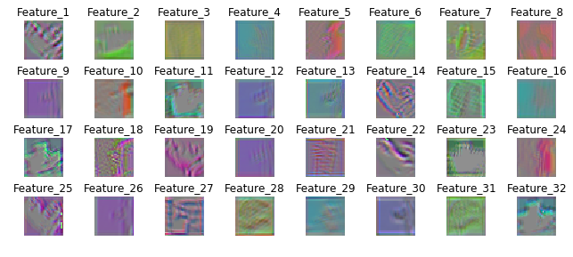

```python
plt.figure(num='CNV1',figsize=(10,8))
for i in range(32):
    isolated = activations1.copy()
    isolated[:,:,:,:i] = 0
    isolated[:,:,:,i+1:] = 0

    totals = np.sum(isolated,axis=(1,2,3))
    best = np.argmax(totals,axis=0)

    pixelactive = unConv.eval(feed_dict={featuresReLu1: isolated})
    plt.subplot(4,8,i+1)
    plt.title('Feature_{}'.format(i+1))
    plt.imshow(visstd(pixelactive[best,:,:,:]))
    plt.axis('off')
plt.subplots_adjust(top=0.5, bottom=0.08, left=0.10, right=0.95, hspace=0.5,
                    wspace=0.35)
plt.show()
```

- **Feature Comparison:**
  1. Feature 3 and 4 almost have the same shape but different background colors.
  2. Feature 9, 20 and 26 seem to own same background color and all emphasize the edges on the right side, but Feature 20 has more stripes than 9 and 26.
- **Feature Grouping:**
  1. It's easy to classify Feature 3, 4 and 6 as one group which has emphasize the background instead of edges. The differences between these three features are the background colors.
  2. Feature 17, 23 and 32 seem to own some kind shape which has similiar edges but different colors. Only considering colors, Feature 3, 7 and 28 get the color yellow; 5, 8 can get red and 4, 13, 16, 29 find blue.

#### (ii) Reconstruction From The Second Convolutional Layer (batch):

```python
featuresReLu2 = tf.placeholder("float",[None,16,16,64])
unReLu2 = tf.nn.relu(featuresReLu2)
unBias2 = unReLu2
unConv2 = tf.nn.conv2d_transpose(unBias2, wConv2,
                                 output_shape=[batchsizeFeatures,16,16,32] ,
                                 strides=[1,1,1,1], padding="SAME")
unPool2 = unpool(unConv2)

unReLu2 = tf.nn.relu(unPool2)
unBias2 = unReLu2
unConv2 = tf.nn.conv2d_transpose(unBias2, wConv1,
                                 output_shape=[batchsizeFeatures,
                                               imagesize,imagesize,3],
                                 strides=[1,1,1,1], padding="SAME")
activations2 = relu2.eval(feed_dict={img: inputImage, lbl: inputLabel, keepProb: 1.0})
```

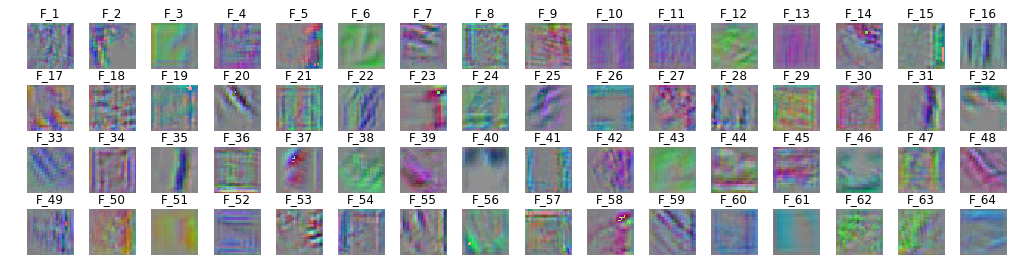

```python
plt.figure(num='CNV2',figsize=(16,8))
for i in range(64):
    isolated = activations2.copy()
    isolated[:,:,:,:i] = 0
    isolated[:,:,:,i+1:] = 0
    #These two lines set all other features other than feature i to 0

    totals = np.sum(isolated,axis=(1,2,3))
    best = np.argmax(totals,axis=0)

    """
    These two lines are particular for batch of images.
    That means choose one image from this batch of images which
    feacture i can judge best.
   """
    pixelactive = unConv2.eval(feed_dict={featuresReLu2: isolated})


    plt.subplot(4,16,i+1)
    plt.title('F_{}'.format(i+1))
    plt.imshow(visstd(pixelactive[best,:,:,:]))
    plt.axis('off')
plt.subplots_adjust(top=0.5, bottom=0.08, left=0.10, right=0.95, hspace=0.1,
                    wspace=0.35)
plt.show()
```

#### (iii). Reconstruction From The First Convolutional Layer (one image):

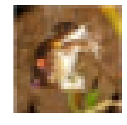

```python
i_data = xs[0]
i_data = i_data/255.0
i_data = np.reshape(i_data,[-1,3,32,32])
i_data = np.swapaxes(i_data,1,3)
plt.imshow(i_data[0,:,:,:])
plt.axis('off')
plt.show()
```

```python
t_data_new = xs[0]
t_data_new = t_data_new/255.0
t_data_new = np.reshape(t_data_new,[-1,3,32,32])
t_data_new = np.swapaxes(t_data_new,1,3)
```

```python
featuresReLu1 = tf.placeholder("float",[None,32,32,32])
unReLu = tf.nn.relu(featuresReLu1)
unBias = unReLu
unConv = tf.nn.conv2d_transpose(unBias, wConv1,
                                output_shape=[1,imagesize,
                                              imagesize,colors],
                                strides=[1,1,1,1], padding="SAME")
activations1 = relu1.eval(feed_dict={img: t_data_new, keepProb: 1.0})
```

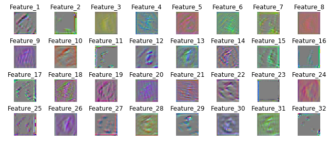

```python
plt.figure(num='CNV1',figsize=(10,8))
for i in range(32):
    isolated = activations1.copy()
    isolated[:,:,:,:i] = 0
    isolated[:,:,:,i+1:] = 0

    pixelactive = unConv.eval(feed_dict={featuresReLu1: isolated})
    plt.subplot(4,8,i+1)
    plt.title('Feature_{}'.format(i+1))
    plt.imshow(visstd(pixelactive[0,:,:,:]))
    plt.axis('off')
plt.subplots_adjust(top=0.5, bottom=0.08, left=0.10, right=0.95, hspace=0.5,
                    wspace=0.35)
plt.show()
```

When we focus on one image, some of these features can be intepret as some parts of the original image.

#### (iv). Reconstruction From The Second Convolutional Layer (one image):

```python
featuresReLu2 = tf.placeholder("float",[None,16,16,64])
unReLu2 = tf.nn.relu(featuresReLu2)
unBias2 = unReLu2
unConv2 = tf.nn.conv2d_transpose(unBias2, wConv2, output_shape=[1,16,16,32] ,
                                 strides=[1,1,1,1], padding="SAME")
unPool2 = unpool(unConv2)

unReLu2 = tf.nn.relu(unPool2)
unBias2 = unReLu2
unConv2 = tf.nn.conv2d_transpose(unBias2, wConv1,
                                 output_shape=[1,imagesize,imagesize,3] ,
                                 strides=[1,1,1,1], padding="SAME")
activations2 = relu2.eval(feed_dict={img: t_data_new, keepProb: 1.0})
```

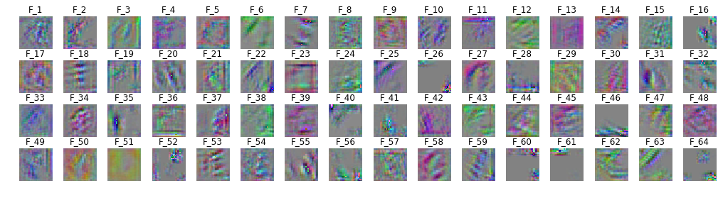

```python
plt.figure(num='CNV2',figsize=(16,8))
for i in range(64):
    isolated = activations2.copy()
    isolated[:,:,:,:i] = 0
    isolated[:,:,:,i+1:] = 0

    pixelactive = unConv2.eval(feed_dict={featuresReLu2: isolated})


    plt.subplot(4,16,i+1)
    plt.imshow(visstd(pixelactive[0,:,:,:]))
    plt.title('F_{}'.format(i+1))
    plt.axis('off')
plt.subplots_adjust(top=0.5, bottom=0.08, left=0.10, right=0.95, hspace=0.1,
                    wspace=0.35)
plt.show()
```

- **Feature Comparison:**
  1. Feature 11 forcus on the top purple but Feature 28 forcus on the bottom.
  2. Feature 23 and 29 seem to have a square inside the image. Feature 23 may tell a black edge and 29 has a yellow edge.
- **Feature Grouping:**
  1. All Feature 6, 25 and 63 concentrate on the left top of the image.
  2. Feature 16 and 37 get the information the right half.

### 3. Deep Dream Feature Visualization

#### (i) Visualizing First Layer：

```python
def vf_layer1(nimg,nf,nit):
    """
    Define the featrue visualization of CNN 1st layer
    nimg = number of image, nf = number of featrue , nit= number of iteration
    """
    t_data = xs[nimg]
    t_data = t_data/255.0
    t_data = np.reshape(t_data,[-1,3,32,32])
    t_data = np.swapaxes(t_data,1,3)

    t_img = tf.placeholder("float",shape=[None,imagesize,imagesize,colors])
    t_bias1 = conv2d(t_img,wConv1) + bConv1
    t_score = tf.reduce_mean(t_bias1[:,:,:,nf])

    t_grad = tf.gradients(t_score, t_img)[0]

    for i in range(nit):
        g, score = sess.run([t_grad, t_score], {t_img:t_data})
        step_size= 1/g.std()+1e-8
        t_data+= g*step_size
    return t_data
```

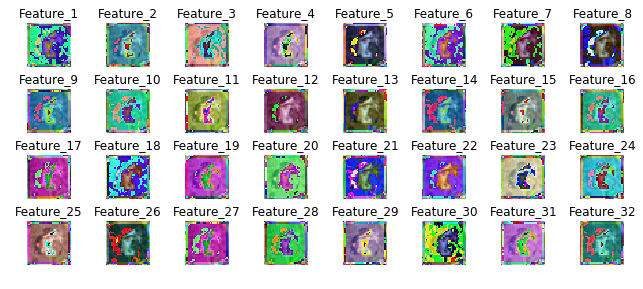

```python
plt.figure(num='CNV1',figsize=(10,8))
for i in range(32):#plot all the 32 features the CNN 1st layer extracts
    plt.subplot(4,8,i+1)
    plt.imshow(vf_layer1(0,i,20)[0,:,:,:])
    plt.title('Feature_{}'.format(i+1))
    plt.axis('off')
plt.subplots_adjust(top=0.5, bottom=0.08, left=0.10, right=0.95, hspace=0.5,
                    wspace=0.35)
plt.show()
```

We can still tell the original image from all 32 features. Also we can see the differences between these features.

#### (ii) Visualizing Second Layer:

```python
def vf_layer2(nimg,nf,nit):

    """
    Define the featrue visualization of CNN 2nd layer
    nimg = number of image, nf = number of featrue , nit= number of iteration
    """

    t_data_new = xs[nimg]
    t_data_new = t_data_new/255.0
    t_data_new = np.reshape(t_data_new,[-1,3,32,32])
    t_data_new = np.swapaxes(t_data_new,1,3)
    t_img_new = tf.placeholder("float",shape=[None,imagesize,imagesize,colors])


    t_bias1 = conv2d(t_img_new,wConv1) + bConv1
    t_relu1 = tf.nn.relu(t_bias1)
    # maxpool to 16x16
    t_pool1 = maxPool2d(t_relu1)
    # second conv layer, takes a 16x16 with 32 layers, turns to 8x8 with 64 layers
    t_bias2 = conv2d(t_pool1,wConv2) + bConv2




    t_score_new = tf.reduce_mean(t_bias2[:,:,:,nf])
    t_grad_new = tf.gradients(t_score_new, t_img_new)[0]



    for i in range(nit):
        g_new, score_new = sess.run([t_grad_new, t_score_new], {t_img_new:t_data_new})
        step_size= 1/g_new.std()+1e-8
        t_data_new+= g_new*step_size
    return t_data_new
```

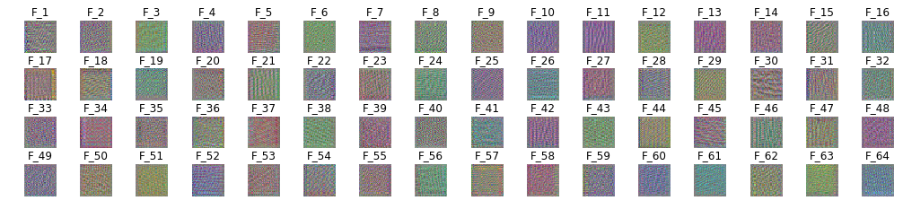

```python
plt.figure(num='CNV2',figsize=(16,16))
for i in range(64):#plot all the 64 features the CNN 2nd layer extracts
    plt.subplot(4,16,i+1)
    plt.imshow(visstd(vf_layer2(0,i,30)[0,:,:,:]))
    plt.title('F_{}'.format(i+1))
    plt.axis('off')
plt.subplots_adjust(top=0.25, bottom=0.08, left=0.10, right=0.95, hspace=0.5,
                    wspace=0.35)
plt.show()
```

When things come to the second layer, all features showed above seem to have some kinds of patterns. Comparing with the first layer, we cannot tell the original image from these plots. These features may give some information to help the neural network recognize which class the original image belongs to.

- **Feature Grouping:**
  1. Feature 5, 7, 17 and 45 show some horizontal stripes and at the same time 13, 23, 31 and 42 show some vertical stripes.
  2. Feature 6, 38, 43 and 36 extract color green and 10, 11, 42, 48 find color purple.